# Testing Regression Model for Citibike Trips

Nava Nizard (Hunter College)

2026-06-15

```r
repo = "https://cran.r-project.org"

install.packages("httpgd", repos = repo)
library(tidyverse)
library(modelr)
library(scales)
library(httpgd)
httpgd::hgd()
```

```
## httpgd server running at:
##   http://127.0.0.1:54360/live?token=fLhyyiSz
```

```r
theme_set(theme_bw())

knitr::opts_chunk$set(echo = TRUE)

setwd("c:/Users/nava/Documents/coursework/week4/")

load("c:/Users/nava/Documents/coursework/week3/final_model.RData")
```

## Load data

```r
trips_per_day <- read_tsv("trips_per_day_2015.tsv")
weather <- read_csv("weather_2015.csv") %>%
    rename("ymd" = "DATE",
           "prcp" = "PRCP",
           "snow" = "SNOW",
           "snwd" = "SNWD",
           "tmax" = "TMAX",
           "tmin" = "TMIN")
trips_with_weather <- left_join(trips_per_day, weather, by = "ymd") %>%
    select(-STATION, -NAME, -TAVG)
```

## Feature Engineer New Data Set

```r
# make sure to have same fields used in the model
trips_with_weather <- trips_with_weather %>% filter(year(ymd) <= 2015)
trips_with_weather <- trips_with_weather %>%
    mutate(tmin = tmin * 0.1, tmax = tmax * 0.1) %>%
    mutate(season = case_when(month(ymd) == 12 | month(ymd) == 1 | month(ymd) == 2 ~ "winter",
                              month(ymd) == 3  | month(ymd) == 4 | month(ymd) == 5 ~ "spring",
                              month(ymd) == 6  | month(ymd) == 7 | month(ymd) == 8 ~ "summer",
                              month(ymd) == 9  | month(ymd) == 10 | month(ymd) == 11 ~ "fall")) %>%
    mutate(day_of_the_week = wday(ymd, label = TRUE)) %>%
    group_by(season) %>%
    mutate(rain_lvl = case_when(prcp <= mean(prcp) ~ "low",
                            prcp > mean(prcp) ~ "high")) %>%
    mutate(avg_temp = (tmin + tmax) / 2) %>%
    mutate(avg_temp = case_when(avg_temp <= mean(avg_temp) ~ "cold",
                                avg_temp > mean(avg_temp) ~ "hot"))

# View(trips_with_weather)
# View(train)
```

```r
test_predictions <- predict(final_model, trips_with_weather)
test_rmse <- rmse(final_model, trips_with_weather)
```

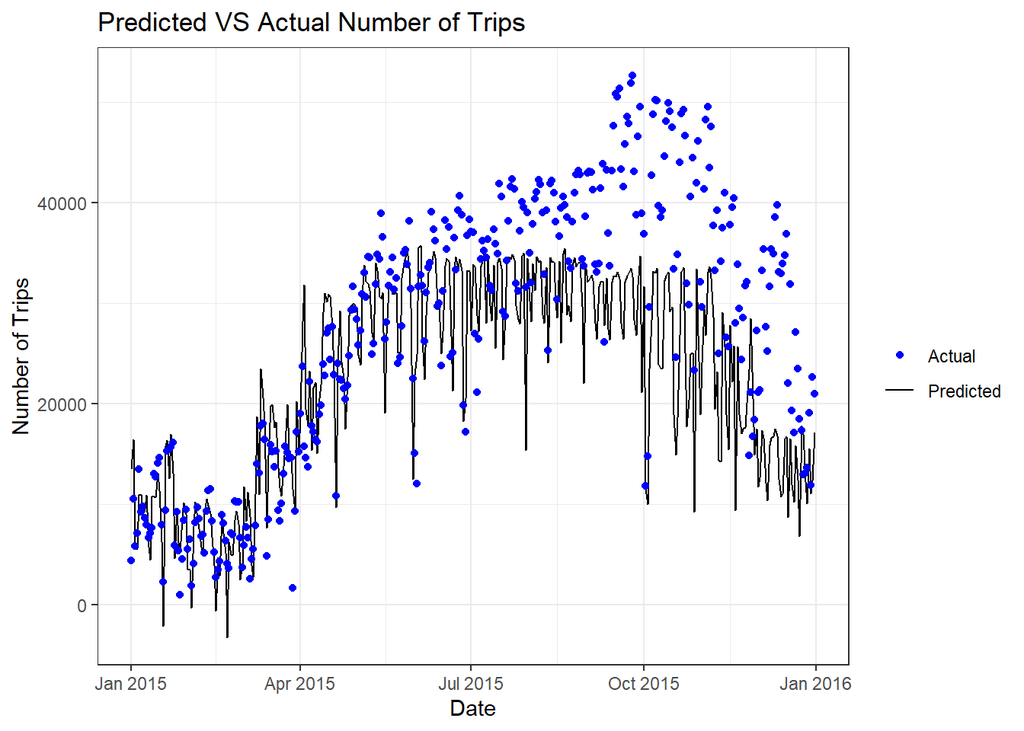

```r
plot_test_data <- data.frame(ymd = trips_with_weather$ymd, actual_trips = trips_with_weather$num_trips, test_predictions)

ggplot(plot_test_data, aes(x = ymd)) +
    geom_line(aes(y = test_predictions, color = "Predicted")) +
    geom_point(aes(y = actual_trips, color = "Actual")) +
    scale_color_manual(values = c("Predicted" = "black",
                                   "Actual" = "blue")) +
    labs(x = 'Date',
         y = 'Number of Trips',
         title = 'Predicted VS Actual Number of Trips',
         color = "",)
```

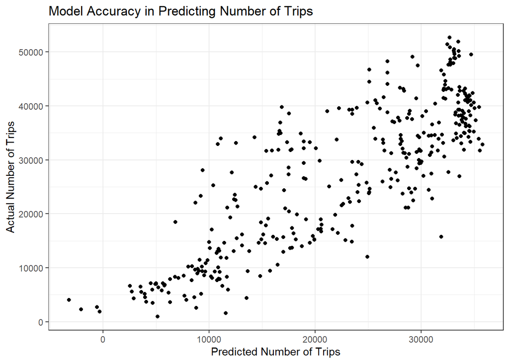

```r
ggplot(plot_test_data, aes(x = test_predictions, y = actual_trips)) +
    geom_point() +
    labs(x = 'Predicted Number of Trips',
         y = 'Actual Number of Trips',
         title = 'Model Accuracy in Predicting Number of Trips')
```

## Conclusion

When I first tested my model on the test set, I got a very large RMSE of about 120,000 trips and noticed some huge spikes in the predictions. After investigating, I realized that the issue was coming from my feature engineering. I had originally created `avg_temp` and `rain_lvl` using averages across the entire year instead of grouping by season first. This caused some days to be classified in a way that created extra fluctuations in the predictions.

After fixing this by grouping by season before calculating these variables, the RMSE decreased a lot to 8813.3910171 trips. (I know that you’re not supposed to change your model after looking at the test results, but in this case I was correcting a mistake in my feature engineering rather than intentionally tuning the model to perform better on the test set.)